# Jak stopy procentowe NBP wpływają na inflację w Polsce?

Analiza wektorowej autoregresji (VAR), 2002–2026

Autor

Miłosz Żyto

Opublikowano

13 października 2026

# Streszczenie

**Pytanie.** Czy podwyżka stóp procentowych przez NBP obniża inflację w Polsce i po jakim czasie?

**Odpowiedź w trzech zdaniach.**

1. W danych miesięcznych z lat 01.2002–08.2026 **nie ma dowodu, że niespodziewana podwyżka stopy referencyjnej obniża inflację**. Po szoku o 25 pb poziom cen rośnie o ok. 0,47% po roku (przedział 90%: 0,11 do 0,80%). Efekt pojawia się po ok. 5 miesiącach, osiąga szczyt po 14 miesiącach i wygasa po ok. 31 miesiącach.
2. To **nie znaczy, że podwyżki podnoszą inflację**. Znaczy, że model nie potrafi oddzielić „nieoczekiwanej decyzji” od reakcji NBP na inflację, którą widzi, a model nie: stopa głównie *reaguje* na inflację (test Grangera inflacja → stopa: p = 0,014), a nie odwrotnie (stopa → inflacja: p = 0,19). W literaturze to zjawisko nazywa się *zagadką cenową* (*price puzzle*).
3. Wynik jest silnie zależny od okresu: w próbie do 2019 r. reakcja cen jest bliska zera (0,11%, przedział obejmuje zero), a w próbach obejmujących lata 2020–2023 (COVID, szok inflacyjny) jest dodatnia i istotna. **Z tych danych i tej metody nie da się wiarygodnie ocenić siły oddziaływania stóp na inflację w Polsce**; zobacz Ograniczenia.

**AdnotacjaJak czytać wyniki bez znajomości ekonometrii**

*Szok monetarny* to decyzja o stopie, która była zaskoczeniem. Gdy bank podnosi stopy dokładnie wtedy, gdy rynek się tego spodziewał, a przyczyną jest rosnąca inflacja, nie widać „czystego” efektu stóp: widać raczej, że inflacja i stopy rosły razem. Metoda VAR próbuje wydzielić ten „czysty” składnik, ale robi to na podstawie założeń, które tutaj nie w pełni się sprawdzają.

# 1 Dane

Tabela 1: Źródła danych

| Zmienna | Źródło | Zakres | Uwagi |
| --- | --- | --- | --- |
| Stopa referencyjna NBP | NBP, archiwum zmian stóp (XML), stan na koniec miesiąca | 01.2002–08.2026 | zgodna z danymi BIS w 344 z 344 wspólnych miesięcy |
| Inflacja HICP, r/r | Eurostat, `prc_hicp_minr`, `RCH_A` | od 01.1997 | pierwsze 12 miesięcy 1996 to braki (r/r wymaga historii) |
| Inflacja HICP, m/m | Eurostat, `prc_hicp_minr`, `RCH_M` | od 02.1996 | niewyrównana sezonowo |
| EUR/PLN | NBP API, tabela A, średnia z notowań w miesiącu | od 01.2002 | ponad 6 tys. notowań dziennych |
| Produkcja przemysłowa | Eurostat, `sts_inpr_m` (B–D, wyrównana, 2021 = 100) | od 01.2000 | zmienna kontrolna |
| Ropa Brent | FRED/EIA, średnia miesięczna, USD/baryłkę | od 1987 | zmienna kontrolna |

Wspólny zakres czterech głównych zmiennych to **01.2002–08.2026** (296 miesięcy, bez luk). Dane pobrano 13.10.2026.

**Weryfikacja danych (co sprawdzono, zanim zaufano wynikom).**

- *Klasyfikacja Eurostatu.* Od danych za 01.2026 Eurostat używa ECOICOP v2 (`coicop18`), a stare tabele (`prc_hicp_manr`, `CP00`) są zarchiwizowane i urywają się w 12.2025. Użyto nowej tabeli. Na wspólnym okresie obie wersje różnią się o co najwyżej 0,2 pp.
- *Stopa NBP.* Atrybut `data_publikacji` w archiwum XML wskazuje 2015 r., choć treść sięga marca 2026 r. Aktualność oceniono po ostatniej dacie zmiany i po zgodności z BIS, nie po tym atrybucie. Stan na koniec miesiąca zgadza się z BIS w każdym miesiącu; średnia ważona dniami nie (78 miesięcy z różnicą > 0,05 pp), więc użyto stanu na koniec miesiąca.
- *Spójność inflacji.* Skumulowane 12 miesięcy inflacji m/m odtwarza r/r z dokładnością do zaokrągleń (maks. 0,3 pp).
- *Ostatni miesiąc.* Dane o inflacji kończą się w 08.2026; wrzesień 2026 nie został jeszcze opublikowany, a październik w kursie EUR/PLN jest niepełny, więc oba pominięto.

# 2 Eksploracja

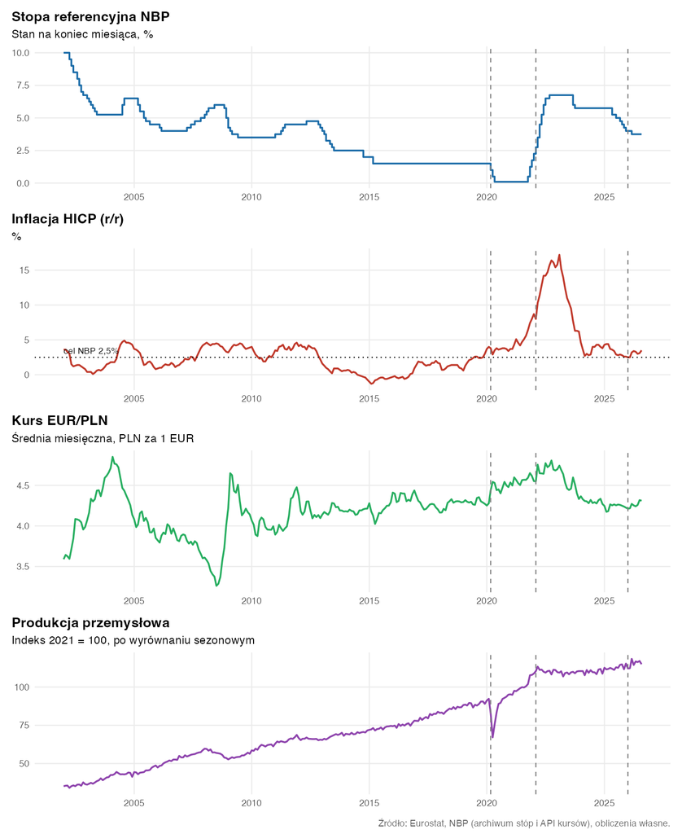

Rysunek 1: Szeregi w poziomach, 2002–2026. Linie przerywane: COVID-19 (03.2020), szok inflacyjny (02.2022), zmiana klasyfikacji Eurostatu (01.2026).

Co widać:

- **Stopa NBP** spadała od 10% (2002) do 1,5% (2015–2020), spadła niemal do zera w 2020 r. (0,10% od 05.2020 do 09.2021), po czym została gwałtownie podniesiona do 6,75% w 2022–2023 r. i od 2025 r. jest obniżana (obecnie 3,75%). W latach 2020–2021 działało **ograniczenie dolne** stóp, co utrudnia estymację liniowego modelu.
- **Inflacja** przez większość próby mieściła się w pobliżu celu (2,5%), po czym w 2022 r. gwałtownie wzrosła, osiągając 17,2% w 02.2023. Jest to największa obserwacja nietypowa w próbie i silnie wpływa na wyniki.
- **Kurs EUR/PLN** wahał się w przedziale 3,26–4,85, z silnym osłabieniem złotego w 2008–2009 r. i w 2020–2022 r.
- **Produkcja** ma silny trend, a w 2020 r. załamanie i szybkie odbicie.

W poziomach stopa i inflacja są skorelowane dodatnio (r = 0,37), ale to korelacja na trendach i okresach, nie dowód zależności (zob. następny rozdział).

# 3 Stacjonarność

## 3.1 Dlaczego to ważne

Regresja jednego trendującego szeregu na drugim często wygląda „świetnie”, nawet gdy szeregi nie mają ze sobą nic wspólnego. To **regresja pozorna** (Granger i Newbold, 1974). Sprawdziłem to na symulacji: dla 2000 par *niezależnych* błądzeń losowych o długości 296 (tak jak w naszej próbie) test t uznaje związek za istotny w **87% przypadków** (powinno być 5%), przeciętne R² wynosi 0,25, a statystyka Durbina–Watsona 0,05 (wartość bliska 0 oznacza silnie autokorelowane reszty). Na prawdziwych danych regresja inflacji na stopie w poziomach daje R² = 0,14 i DW = 0,02. To symptom regresji pozornej. Ta sama regresja na różnicach ma DW = 1,43.

Dlatego przed budową VAR sprawdzamy, czy szeregi są stacjonarne (nie mają trwałego trendu i pierwiastka jednostkowego).

## 3.2 Testy

Test ADF: hipoteza zerowa = niestacjonarność. Test KPSS: hipoteza zerowa = stacjonarność. Gdy oba wskazują to samo, wniosek jest pewny.

Tabela 2: Testy pierwiastka jednostkowego (ADF, KPSS). Przedrostek „d_” oznacza pierwszą różnicę; log × 100 dla kursu i produkcji.

| Szereg | Specyfikacja | ADF tau | Wart. kryt. 5% | ADF: stacjonarny | KPSS p | KPSS: stacjonarny |
| --- | --- | --- | --- | --- | --- | --- |
| stopa | drift | -2,58 | -2,87 | nie | 0,010 | nie |
| stopa | trend | -2,55 | -3,42 | nie | 0,010 | nie |
| d_stopa | drift | -6,19 | -2,87 | tak | 0,100 | tak |
| inflacja | drift | -1,86 | -2,87 | nie | 0,010 | nie |
| inflacja | trend | -1,95 | -3,42 | nie | 0,010 | nie |
| d_inflacja | drift | -6,94 | -2,87 | tak | 0,100 | tak |
| leurpln | drift | -2,94 | -2,87 | tak | 0,010 | nie |
| leurpln | trend | -3,35 | -3,42 | nie | 0,023 | nie |
| d_leurpln | drift | -7,55 | -2,87 | tak | 0,100 | tak |
| lprodukcja | drift | -1,68 | -2,87 | nie | 0,010 | nie |
| lprodukcja | trend | -3,65 | -3,42 | tak | 0,010 | nie |
| d_lprodukcja | drift | -14,62 | -2,87 | tak | 0,100 | tak |

**Decyzja.**

- **Stopa, kurs (log) i produkcja (log)** są niestacjonarne w poziomach: KPSS odrzuca stacjonarność wszędzie, a ADF nie odrzuca pierwiastka jednostkowego w większości specyfikacji (wyjątki: kurs ze stałą, tau = −2,94 przy wartości krytycznej −2,87, i produkcja z trendem, ale w obu KPSS i tak wskazuje niestacjonarność). Pierwsze różnice są stacjonarne w obu testach, więc do modelu wchodzą jako pierwsze różnice. Wartości p testu KPSS są interpolowane i ograniczone do przedziału 0,01–0,10.
- **Inflacja r/r** też jest niestacjonarna w poziomach, ale jej różnica ma problem techniczny: Δ(r/r) = π(t) − π(t−12) ma mechanicznie ujemną autokorelację na opóźnieniu 12 (efekt bazy; w danych −0,36), co psuje diagnostykę. Dlatego w modelu użyto **inflacji m/m**, która takiej cechy nie ma, ale ma sezonowość (stąd dummies miesięczne).
- **Inflacja m/m** po usunięciu sezonowości: ADF odrzuca pierwiastek jednostkowy (tau = -3,18), ale KPSS odrzuca stacjonarność (p = 0,010). W próbie do 2019 r. oba testy wskazują stacjonarność. Rozbieżność wynika z przesunięcia średniej inflacji w latach 2021–2023. Traktuję ją jako stacjonarną, **z zastrzeżeniem**, że to założenie jest najsłabszym punktem specyfikacji.

## 3.3 Kointegracja

Jeśli niestacjonarne szeregi mają wspólny trend (są skointegrowane), różnicowanie gubi relację długookresową. Test Johansena daje jednak niespójny obraz: liczba relacji kointegrujących zależy od liczby opóźnień i od próby (Tabela 3). Dla trzech zmiennych wynik „r = 3” oznaczałby, że wszystkie są stacjonarne, co przeczy ADF, więc test przesadnie odrzuca. W próbie do 2019 r. przeważa brak kointegracji. Przyjęto VAR na różnicach jako model główny, a **VAR na poziomach** sprawdzono w rozdziale o odporności (specyfikacja 10; w poziomach estymacja jest zgodna nawet przy kointegracji).

Tabela 3: Liczba relacji kointegrujących (test śladu Johansena, 5%) dla różnych opóźnień K i prób.

| Próba | K = 2 | K = 3 | K = 4 | K = 5 | K = 6 | K = 7 | K = 8 |
| --- | --- | --- | --- | --- | --- | --- | --- |
| pełna próba | 2 | 2 | 2 | 2 | 1 | 3 | 1 |
| do 2019 | 2 | 1 | 0 | 0 | 0 | 0 | 0 |
| od 2010 | 2 | 2 | 1 | 1 | 2 | 1 | 1 |
| bez 2020-2022 | 3 | 2 | 2 | 1 | 1 | 1 | 1 |

# 4 Specyfikacja modelu VAR

## 4.1 Model

VAR to układ równań, w którym każda zmienna zależy od własnych opóźnień i opóźnień pozostałych zmiennych. Główny model ma trzy zmienne: **inflację m/m**, **zmianę stopy NBP** (pp) i **zmianę logarytmu kursu EUR/PLN** (×100, w przybliżeniu % deprecjacji złotego), a także stałą i dummies miesięczne.

## 4.2 Liczba opóźnień

Tabela 4: Kandydaci na liczbę opóźnień. Autokorelacja reszt: chcemy p > 0,05.

| Opóźnienia p | Portmanteau (24), p | Breusch–Godfrey (6), p | Największy pierwiastek | Parametrów na równanie |
| --- | --- | --- | --- | --- |
| 1 | 0,011 | <0,001 | 0,69 | 15 |
| 2 | 0,140 | <0,001 | 0,81 | 18 |
| 3 | 0,371 | <0,001 | 0,87 | 21 |
| 4 | 0,302 | 0,001 | 0,89 | 24 |
| 5 | 0,571 | 0,005 | 0,86 | 27 |
| 6 | 0,599 | 0,266 | 0,86 | 30 |

Kryteria informacyjne dają różne wskazania: AIC i FPE wybierają **p = 3**, HQ i SC wybierają p = 1. Przy p = 1 reszty są jednak wyraźnie autokorelowane (Portmanteau p ≈ 0,01), więc to p odrzucam. Wybrano **p = 3**: to opóźnienie z najniższym AIC i z poprawnymi resztami wg testu Portmanteau. Test Breusch–Godfreya (z 6 i 12 opóźnieniami) nadal odrzuca brak autokorelacji; przechodzi dopiero p = 6, które sprawdzono w rozdziale o odporności (wnioski się nie zmieniają).

## 4.3 Kolejność zmiennych (identyfikacja Choleskiego)

Reszty modelu są ze sobą skorelowane, więc aby mówić o „szoku monetarnym”, trzeba przyjąć założenie o kolejności reakcji w ramach miesiąca (rozkład Choleskiego). Przyjęto:

**inflacja → stopa NBP → kurs EUR/PLN.**

- *Inflacja pierwsza*: ceny konsumenckie są sztywne i nie reagują na decyzję RPP w tym samym miesiącu.
- *Stopa druga*: RPP reaguje na bieżące dane o inflacji. To założenie jest ostrożne: korelacja reszt inflacja–stopa wynosi 0,23, więc odwrócenie kolejności przypisałoby tę wspólną część „szokowi stopy” i nasiliło zagadkę cenową (specyfikacja 6).
- *Kurs ostatni*: kurs walutowy to cena aktywa reagująca natychmiast na decyzję RPP, ale w rzeczywistości także na całą informację rynkową.

To standardowy schemat (Christiano, Eichenbaum i Evans, 1999), ale **jest to założenie, nie wynik**. Zbadano także kolejność odwrotną (stopa pierwsza) i kurs przed stopą.

## 4.4 Estymacja

**Pokaż kod**

```r
dane_var <- readRDS("data/processed/dane_var.rds")
model <- estymuj_var(dane_var, c("inflacja_mm", "d_stopa", "d_eurpln"), p = 3)  # vars::VAR, stała + dummies miesięczne
summary(model)
```

Próba efektywna: 292 obserwacji (05.2002–08.2026).

# 5 Diagnostyka modelu

Tabela 5: Diagnostyka modelu bazowego VAR(3).

| Test | H0 | p | Wynik | Co robić, gdy nie przechodzi |
| --- | --- | --- | --- | --- |
| Pierwiastki | stabilność (moduły < 1) | – | OK | zmienić transformację/różnicowanie, sprawdzić liczbę opóźnień |
| Portmanteau(24) | brak autokorelacji reszt | 0,371 | OK | zwiększyć p, dodać dummies/zmienną |
| Breusch-Godfrey(6) | brak autokorelacji reszt | <0,001 | NIE | zwiększyć p (sprawdzić p = 6 w etapie 7) |
| Jarque-Bera (wielowym.) | normalność reszt | <0,001 | NIE | bootstrap reszt zamiast przedziałów normalnych; dummies na odstające |
| ARCH-LM(5) | homoskedastyczność | <0,001 | NIE | okres bez 2020-2022; bootstrap; interpretować przedziały ostrożnie |

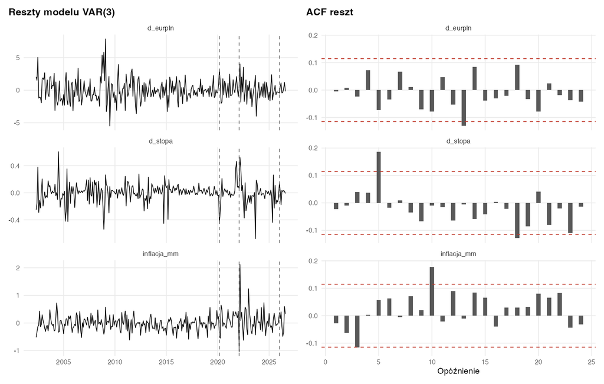

Rysunek 2: Reszty modelu i ich autokorelacja. Największe wahania przypadają na lata 2020–2023.

**Co przechodzi.** Model jest *stabilny* (największy pierwiastek 0,87 < 1), więc funkcje reakcji na impuls wygasają, a reszty nie są autokorelowane wg testu Portmanteau.

**Co nie przechodzi, i co to oznacza.**

- *Normalność i heteroskedastyczność* (JB, ARCH): odrzucone silnie. Reszty mają grube ogony (kurtoza inflacji m/m ≈ 11) i zmienną wariancję: odchylenie reszt inflacji jest w latach 2020–2022 ok. dwa razy większe niż wcześniej. Główne źródło to marzec 2022 r. (inflacja m/m +2,1 pp, ok. 7 odchyleń standardowych). *Konsekwencja:* przedziały ufności z założeniem normalności byłyby zawodne, więc użyto **bootstrapu reszt**, a wyniki sprawdzono z dummies na odstające obserwacje i na krótszych próbach. Istotność oceniano testami odpornymi (HC1).
- *Breusch–Godfrey*: odrzuca brak autokorelacji, choć Portmanteau nie. Autokorelacja jest słaba (kilka opóźnień nieznacznie przekracza pasmo). Sprawdzono p = 6.
- *Stabilność parametrów* (CUSUM): przekroczona dla równania inflacji, co odpowiada **zmianie reżimu** w 2021–2023. To jedno z głównych ograniczeń analizy.

# 6 Wyniki

## 6.1 Przyczynowość w sensie Grangera

Test Grangera pyta: czy przeszłe wartości zmiennej X pomagają przewidywać Y ponad to, co wynika z przeszłości samego Y? To przewidywalność, a nie przyczynowość w sensie potocznym.

Tabela 6: Testy Grangera, VAR(3). Odporny test uwzględnia heteroskedastyczność.

| Przyczyna | Skutek | F | p (klasyczny) | p (odporny, HC1) |
| --- | --- | --- | --- | --- |
| d_stopa | inflacja_mm | 3,03 | 0,030 | 0,186 |
| inflacja_mm | d_stopa | 5,18 | 0,002 | 0,014 |
| d_eurpln | inflacja_mm | 3,56 | 0,015 | 0,002 |
| inflacja_mm | d_eurpln | 0,52 | 0,667 | 0,692 |
| d_stopa | d_eurpln | 2,20 | 0,088 | 0,214 |
| d_eurpln | d_stopa | 2,22 | 0,086 | 0,305 |

- **Inflacja → stopa:** istotna (p = 0,014): NBP reaguje na inflację, co jest zgodne z regułą polityki pieniężnej.
- **Stopa → inflacja:** nieistotna w teście odpornym (p = 0,186); istotna dopiero w klasycznym teście (p = 0,030), który nie jest odporny na zmienną wariancję reszt.
- **Kurs → inflacja:** istotne (p = 0,002), co jest zgodne z przenoszeniem zmian kursu na ceny.

## 6.2 Funkcje reakcji na impuls (IRF)

IRF pokazuje, jak zmienne reagują w kolejnych miesiącach na jednorazowy, nieoczekiwany wzrost stopy NBP o 25 pb (typowy krok RPP). Przedziały pochodzą z bootstrapu reszt (1000 replikacji).

**Pokaż kod**

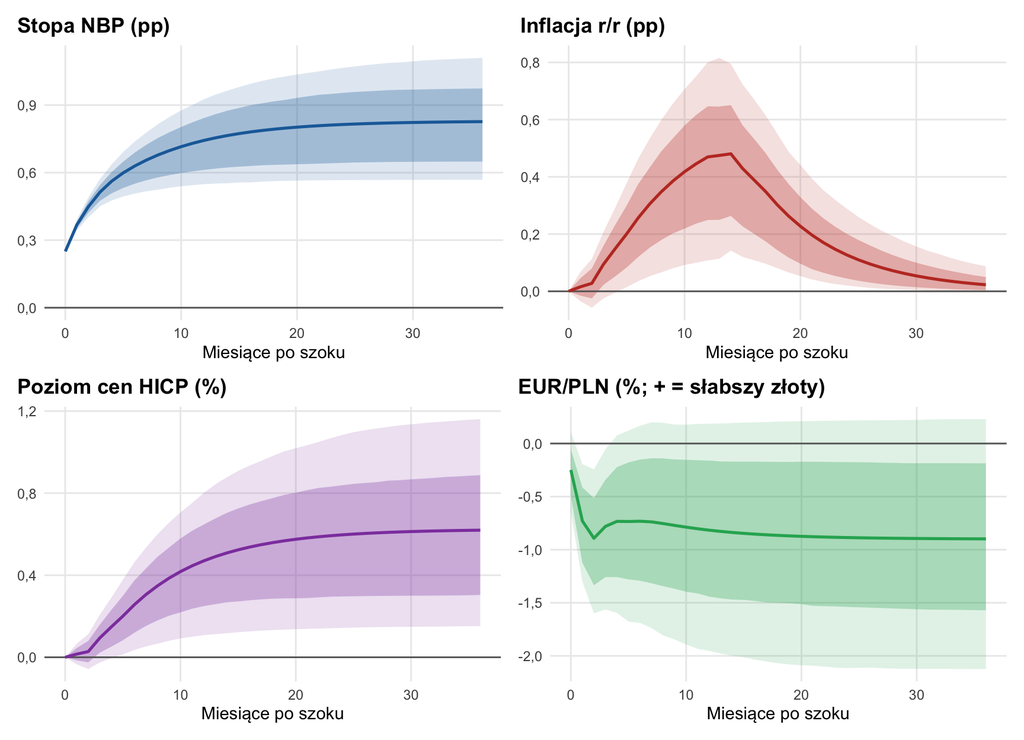

Rysunek 3: Reakcja na nieoczekiwany wzrost stopy NBP o 25 pb. Linia: estymacja punktowa; pasma: 68% i 90%.

```r
pasma <- \(wielkosc, tytul, kolor) {
  przedzialy(bt, wielkosc) |>
    ggplot(aes(h)) +
    geom_ribbon(aes(ymin = lo90, ymax = hi90), fill = kolor, alpha = 0.15) +
    geom_ribbon(aes(ymin = lo68, ymax = hi68), fill = kolor, alpha = 0.30) +
    geom_hline(yintercept = 0, color = "grey40") +
    geom_line(aes(y = punkt), color = kolor, linewidth = 0.9) +
    labs(title = tytul, x = "Miesiące po szoku", y = NULL) + motyw_projektu()
}
library(patchwork)
(pasma("stopa_poziom", "Stopa NBP (pp)", "#1b6ca8") + pasma("infl_rr", "Inflacja r/r (pp)", "#c0392b")) /
(pasma("ceny_poziom", "Poziom cen HICP (%)", "#8e44ad") + pasma("kurs_poziom", "EUR/PLN (%; + = słabszy złoty)", "#27ae60"))
```

Tabela 7: Reakcja na szok +25 pb: estymacja punktowa i [przedział 90%].

| Po ilu miesiącach | Poziom cen (%) | Inflacja r/r (pp) | EUR/PLN (%) |
| --- | --- | --- | --- |
| 6 | 0,26 [0,04; 0,46] | 0,26 | -0,73 [-1,69; 0,17] |
| 12 | 0,47 [0,11; 0,80] | 0,47 [0,11; 0,80] | -0,82 [-1,95; 0,19] |
| 24 | 0,60 [0,14; 1,08] | 0,13 | -0,89 [-2,11; 0,22] |

Interpretacja:

- **Stopa:** po szoku +25 pb poziom stopy dalej rośnie (do ok. 0,81 pp po dwóch latach), bo zmiany stóp są autokorelowane (cykle podwyżek).
- **Ceny:** poziom cen **rośnie**, nie spada. Dodatnia reakcja jest statystycznie istotna od ok. 5 miesiąca. To zagadka cenowa.
- **Inflacja r/r:** zmiana poziomu cen w ciągu ostatnich 12 miesięcy; szczyt 0,48 pp po 14 miesiącach, potem wygasanie.
- **Kurs:** złoty się *umacnia* (EUR/PLN spada o ok. 0,82% po roku), co jest zgodne z teorią, ale przedział 90% obejmuje zero, więc efekt jest niepewny.

## 6.3 Dekompozycja wariancji (FEVD)

Jaką część nieprzewidywalnej zmienności inflacji wyjaśnia każdy szok?

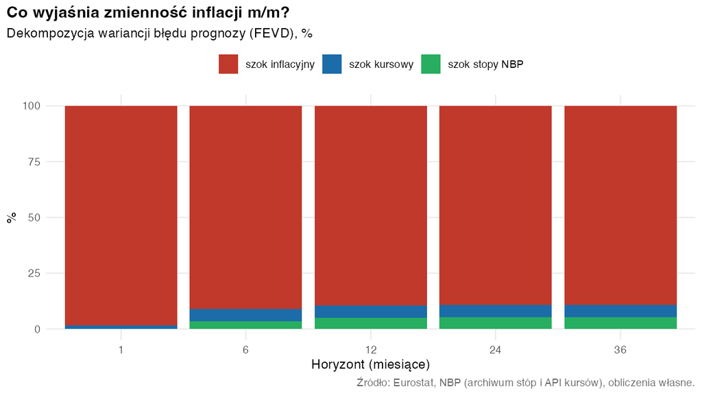

Rysunek 4: Dekompozycja wariancji błędu prognozy inflacji m/m.

Po roku szok stopy NBP wyjaśnia ok. **5,1%** zmienności inflacji (przedział 90%: 0,9–13,5%), szok kursowy ok. 5,5%, a **ok. 89% to własne, nieobjaśnione szoki inflacji** (m.in. ceny energii i żywności, które model ujmuje tylko pośrednio). Odwrotnie, ok. 25% zmienności stopy wyjaśnia inflacja (reguła reakcji NBP).

# 7 Odporność wyników

Ta sama analiza (IRF, Granger, FEVD) została powtórzona w 10 wariantach: inne opóźnienia, inne okresy, odwrócona kolejność, dummies na obserwacje odstające, dodatkowe zmienne (produkcja, ropa) i VAR na poziomach.

Tabela 8: Odporność: reakcja na szok stopy +25 pb (estymacja punktowa i przedział 90%) oraz testy Grangera (odporne).

| Specyfikacja | T | Ceny po 12 mies. (%) | EUR/PLN po 12 mies. (%) | Granger stopa→infl., p | Granger infl.→stopa, p |
| --- | --- | --- | --- | --- | --- |
| 1. Bazowy: VAR(3), pełna próba | 292 | 0,47 [0,11; 0,81] | -0,82 [-1,86; 0,14] | 0,186 | 0,014 |
| 2. Więcej opóźnień: VAR(6) | 289 | 0,54 [0,12; 0,96] | -0,51 [-1,63; 0,84] | 0,128 | 0,045 |
| 3. Próba od 2010 | 197 | 0,72 [0,07; 1,27] | 0,46 [-0,31; 1,24] | 0,444 | 0,155 |
| 4. Próba do 2019 (przed COVID) | 212 | 0,11 [-0,10; 0,33] | -2,05 [-3,66; -0,54] | 0,132 | 0,037 |
| 5. Dummies na odstające (2022-02/03, 2023-01) | 292 | 0,37 [0,09; 0,66] | -1,10 [-2,17; -0,13] | 0,008 | <0,001 |
| 6. Odwrócona kolejność: stopa -> inflacja -> kurs | 292 | 0,79 [0,34; 1,18] | -1,00 [-2,08; 0,02] | 0,186 | 0,014 |
| 7. Kurs przed stopą: inflacja -> kurs -> stopa | 292 | 0,51 [0,16; 0,83] | -0,48 [-1,49; 0,44] | 0,186 | 0,014 |
| 8. + produkcja przemysłowa (4 zm.) | 292 | 0,50 [0,14; 0,83] | -0,76 [-1,78; 0,18] | 0,192 | 0,016 |
| 9. + ropa Brent i produkcja (5 zm.) | 292 | 0,51 [0,13; 0,88] | -0,72 [-1,86; 0,20] | 0,179 | 0,032 |
| 10. VAR na poziomach (stopa, kurs w poziomach), p = 4 | 291 | 0,24 [-0,17; 0,53] | -0,45 [-1,15; 0,20] | 0,308 | 0,004 |

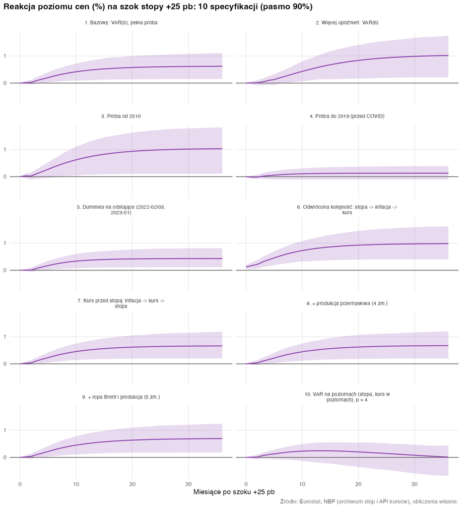

Rysunek 5: Reakcja poziomu cen na szok stopy +25 pb w 10 specyfikacjach (pasmo 90%).

**Co jest stabilne:**

- Znak „zagadki cenowej” (dodatnia reakcja poziomu cen po 12 miesiącach) jest taki sam w 10 z 10 specyfikacji. Przedział 90% nie obejmuje zera w 8 z 10.
- *Inflacja → stopa* jest istotna (p < 0,05) w 9 z 10 specyfikacji; *stopa → inflacja* tylko w 1 z 10 (w specyfikacji z dummies na odstające, gdzie – z powodu osobliwej macierzy odpornej – użyto testu klasycznego), więc ta zależność nie jest odporna.
- Dodanie produkcji i ropy (spec. 8–9) nie usuwa zagadki; zmiana kolejności (spec. 6–7) zmienia jej wielkość, nie znak.

**Wniosek:** wnioski jakościowe (NBP reaguje na inflację, w 9 z 10 specyfikacji; brak dowodu na obniżanie inflacji po szoku stopy) są stabilne. Ilościowe oszacowania nie są.